# Multilevel analysis of protection behaviors: Accounting for geographic clustering in KAP outcomes

This is an analysis pre-testing

Juan Carlos Ocampo

2025-12-15

# 1 Scientific rationale

Mosquito-borne disease risk, protective behaviors, and related knowledge are not randomly distributed across metropolitan France. Individuals living in the same région or département share common environmental exposures (Aedes colonization status, climate), health infrastructure (ARS communication campaigns), and social contexts. Ignoring this geographic clustering violates the independence assumption of standard regression, potentially leading to underestimated standard errors and inflated Type I error rates.

Multilevel modeling partitions variance between individual-level and contextual-level factors, providing unbiased estimates and enabling explicit examination of how regional characteristics influence individual behaviors.

This analysis directly supports **Aim 2** by quantifying how geographic context shapes KAP outcomes, informing region-specific intervention strategies.

## 1.1 Theoretical foundation

The **Extended Parallel Process Model** (Witte, 1992) suggests that protective behavior adoption requires both sufficient threat perception AND self-efficacy, conditions that may vary systematically by region.

## 1.2 Research Hypotheses

### 1.2.1 Clustering

**H1**: Significant variance in protection behavior adoption exists at the regional level (ICC > 0.05), justifying multilevel analysis.

### 1.2.2 Compositional effects

**H2**: Individual-level predictors (knowledge, risk perception, self-efficacy) significantly predict protection behavior after accounting for regional clustering.

### 1.2.3 Contextual effects

**H3**: Regional-level Aedes colonization status explains between-region variance in protection behavior, net of individual characteristics.

### 1.2.4 Cross-level interaction

**H4**: The relationship between individual knowledge and protection behavior is moderated by regional colonization status, with stronger effects in colonized areas where knowledge is more actionable.

### 1.2.5 Proportional variance reduction

**H5**: Adding regional-level predictors significantly reduces between-region variance (proportional change in variance, PCV > 0.10).

# 2 Setup

```
## Packages loaded.
```

# 3 Data preparation

## 3.1 Load data

```
## Dataset dimensions: 4000 observations, 144 variables
##
```

```
## Number of régions: 13
##
```

```
## Number of départements: 96
##
```

## 3.2 Prepare analysis variables

```
## Analysis dataset prepared.
##
```

```
## Observations per région:
##
```

```
##
##       Auvergne-Rhône-Alpes    Bourgogne-Franche-Comté
##                        480                        171
##                   Bretagne        Centre-Val de Loire
##                        191                        149
##                      Corse                  Grand Est
##                         18                        348
##            Hauts-de-France              Île-de-France
##                        340                        768
##                  Normandie         Nouvelle-Aquitaine
##                        193                        381
##                  Occitanie           Pays de la Loire
##                        404                        245
## Provence-Alpes-Côte d'Azur
##                        312
```

## 3.3 Descriptive statistics by level

**Individual-Level Descriptive Statistics (N = 4,000)**

| **Level 1 (Individual)** | **N = 4,000**<sup>1</sup> |
| --- | --- |
| Protection measures (count) | 4.73 (2.06) |
| Knowledge score (0-10) | 4.13 (1.57) |
| Risk perception (1-7) | 3.79 (0.83) |
| Self-efficacy (1-7) | 4.45 (0.75) |
| Severity perception (1-7) | 4.97 (0.77) |
| Bite frequency (1-7) | 3.48 (0.98) |
| Age (years) |  |
| 24 | 782 (20%) |
| 35 | 640 (16%) |
| 45 | 628 (16%) |
| 55 | 744 (19%) |
| 65 | 663 (17%) |
| 75 | 543 (14%) |
| Education level (1-5) |  |
| 1 | 1,489 (37%) |
| 2 | 723 (18%) |
| 3 | 595 (15%) |
| 4 | 579 (14%) |
| 5 | 614 (15%) |
| Female | 2,013 (50%) |

<sup>1</sup> Mean (SD); n (%)

Region-Level Characteristics

Level 2 units (N = 13 régions)

| Région | N | Aedes Colonization (%) | Summer Temp (°C) | Poverty Rate (%) | Urban (%) |
| --- | --- | --- | --- | --- | --- |
| Auvergne-Rhône-Alpes | 480 | 100 | 26 | 13.3 | 63.1 |
| Bourgogne-Franche-Comté | 171 | 88 | 25 | 13.4 | 55.6 |
| Bretagne | 191 | 50 | 21 | 11.1 | 55.5 |
| Centre-Val de Loire | 149 | 83 | 25 | 13.5 | 59.7 |
| Corse | 18 | 100 | 29 | 18.1 | 55.6 |
| Grand Est | 348 | 60 | 25 | 15.1 | 63.2 |
| Hauts-de-France | 340 | 40 | 22 | 18.0 | 67.9 |
| Île-de-France | 768 | 100 | 25 | 16.1 | 82.9 |
| Normandie | 193 | 40 | 22 | 13.7 | 63.7 |
| Nouvelle-Aquitaine | 381 | 92 | 26 | 13.8 | 59.3 |
| Occitanie | 404 | 100 | 29 | 17.5 | 56.4 |
| Pays de la Loire | 245 | 80 | 24 | 11.0 | 56.7 |
| Provence-Alpes-Côte d'Azur | 312 | 100 | 30 | 17.4 | 76.0 |

# 4 Multilevel model fit

We follow a systematic model-building strategy, starting with an unconditional (null) model and progressively adding predictors.

## 4.1 Model 0: Null Model (Random intercept only)

The null model partitions variance into between-region and within-region components, enabling calculation of the Intraclass Correlation Coefficient (ICC).

```
## Linear mixed model fit by REML. t-tests use Satterthwaite's method [
## lmerModLmerTest]
## Formula: protection_count ~ 1 + (1 | region)
##    Data: df_ml
##
## REML criterion at convergence: 14184
##
## Scaled residuals:
##     Min      1Q  Median      3Q     Max
## -3.9139 -0.6020  0.0801  0.7883  3.1566
##
## Random effects:
##  Groups   Name        Variance Std.Dev.
##  region   (Intercept) 2.497    1.580
##  Residual             1.993    1.412
## Number of obs: 4000, groups:  region, 13
##
## Fixed effects:
##             Estimate Std. Error      df t value Pr(>|t|)
## (Intercept)   4.6467     0.4396 11.9738   10.57    2e-07 ***
## ---
## Signif. codes:  0 '***' 0.001 '**' 0.01 '*' 0.05 '.' 0.1 ' ' 1
```

```
##
##    VARIANCE COMPONENTS (Model 0)
##
```

```
## Between-region variance (τ²): 2.4967
##
```

```
## Within-region variance (σ²): 1.9935
##
```

```
##
##  Intraclass Correlation Coefficient (ICC): 0.556
##
```

```
## Interpretation: 55.6 % of variance in protection count is between regions.
##
```

## 4.2 H1: Is regional clustering significant?

```
##   H1: Test of Regional Clustering
##
```

```
## Likelihood Ratio Test statistic: 2960.33
##
```

```
## p-value: < 2.22e-16
##
```

```
## Note: p-value divided by 2 for boundary testing of variance parameter.
##
```

```
##
##   Conclusion: ICC = 0.556 > 0.05. H1 SUPPORTED. Multilevel modeling is justified.
##
```

## 4.3 Model 1: Individual-level predictors only

```
## Linear mixed model fit by REML. t-tests use Satterthwaite's method [
## lmerModLmerTest]
## Formula: protection_count ~ knowledge_c + risk_perception_c + efficacy_c +
##     bite_freq_c + female + age_c + education_c + (1 | region)
##    Data: df_ml
##
## REML criterion at convergence: 14224
##
## Scaled residuals:
##     Min      1Q  Median      3Q     Max
## -3.8992 -0.6057  0.0905  0.7950  3.1739
##
## Random effects:
##  Groups   Name        Variance Std.Dev.
##  region   (Intercept) 2.521    1.588
##  Residual             1.995    1.412
## Number of obs: 4000, groups:  region, 13
##
## Fixed effects:
##                     Estimate Std. Error         df t value Pr(>|t|)
## (Intercept)        4.621e+00  4.422e-01  1.197e+01  10.448 2.28e-07 ***
## knowledge_c       -7.735e-03  1.492e-02  3.981e+03  -0.518    0.604
## risk_perception_c -1.257e-02  2.877e-02  3.983e+03  -0.437    0.662
## efficacy_c        -4.121e-02  3.042e-02  3.981e+03  -1.355    0.176
## bite_freq_c        7.283e-03  3.173e-02  3.992e+03   0.230    0.818
## female             4.984e-02  4.473e-02  3.980e+03   1.114    0.265
## age_c              7.511e-04  1.356e-03  3.980e+03   0.554    0.580
## education_c        1.168e-02  1.580e-02  3.980e+03   0.739    0.460
## ---
## Signif. codes:  0 '***' 0.001 '**' 0.01 '*' 0.05 '.' 0.1 ' ' 1
##
## Correlation of Fixed Effects:
##             (Intr) knwld_ rsk_p_ effcc_ bt_fr_ female age_c
## knowledge_c  0.001
## rsk_prcptn_ -0.001  0.000
## efficacy_c   0.000  0.018 -0.034
## bite_freq_c  0.006 -0.016 -0.004  0.022
## female      -0.050  0.019  0.007  0.024 -0.007
## age_c       -0.001  0.033  0.001 -0.007  0.032 -0.032
## education_c -0.001 -0.109 -0.013 -0.029  0.002 -0.026  0.275
```

```
##
##    Model 1: Variance Explained
##
```

[output not shown]

```
## Proportional Change in Variance (PCV) at Level 2: -1 %
##
```

## 4.4 Model 2: Add region-Level predictors (H3)

```
## Linear mixed model fit by REML. t-tests use Satterthwaite's method [
## lmerModLmerTest]
## Formula: protection_count ~ knowledge_c + risk_perception_c + efficacy_c +
##     bite_freq_c + female + age_c + education_c + aedes_rate_c +
##     temp_c + (1 | region)
##    Data: df_ml
##
## REML criterion at convergence: 14205.8
##
## Scaled residuals:
##     Min      1Q  Median      3Q     Max
## -3.8994 -0.6041  0.0936  0.7969  3.1709
##
## Random effects:
##  Groups   Name        Variance Std.Dev.
##  region   (Intercept) 0.6454   0.8033
##  Residual             1.9946   1.4123
## Number of obs: 4000, groups:  region, 13
##
## Fixed effects:
##                     Estimate Std. Error         df t value Pr(>|t|)
## (Intercept)        4.625e+00  2.264e-01  1.042e+01  20.429 9.65e-10 ***
## knowledge_c       -7.667e-03  1.492e-02  3.982e+03  -0.514   0.6074
## risk_perception_c -1.328e-02  2.877e-02  3.983e+03  -0.462   0.6443
## efficacy_c        -4.172e-02  3.042e-02  3.981e+03  -1.372   0.1703
## bite_freq_c        4.058e-03  3.176e-02  3.984e+03   0.128   0.8983
## female             4.999e-02  4.473e-02  3.980e+03   1.118   0.2638
## age_c              7.286e-04  1.356e-03  3.981e+03   0.537   0.5910
## education_c        1.147e-02  1.579e-02  3.982e+03   0.726   0.4678
## aedes_rate_c       1.457e+00  1.764e+00  1.004e+01   0.826   0.4279
## temp_c             4.027e-01  1.509e-01  1.025e+01   2.668   0.0231 *
## ---
## Signif. codes:  0 '***' 0.001 '**' 0.01 '*' 0.05 '.' 0.1 ' ' 1
##
## Correlation of Fixed Effects:
##             (Intr) knwld_ rsk_p_ effcc_ bt_fr_ female age_c  edctn_ ads_r_
## knowledge_c  0.001
## rsk_prcptn_ -0.001  0.000
## efficacy_c  -0.001  0.018 -0.034
## bite_freq_c  0.011 -0.016 -0.003  0.022
## female      -0.098  0.019  0.007  0.024 -0.007
## age_c       -0.002  0.033  0.001 -0.007  0.032 -0.032
## education_c -0.002 -0.109 -0.013 -0.028  0.003 -0.026  0.275
## aedes_rat_c -0.005 -0.002 -0.003 -0.006 -0.037 -0.001  0.000  0.004
## temp_c       0.011 -0.009 -0.019 -0.006 -0.020  0.002 -0.004 -0.006 -0.825
```

```
##
##    H3 & H5: Contextual effects
##
```

```
## Between-region variance reduced from 2.4967 to 0.6454
##
```

```
## Total PCV at level 2: 74.2 %
##
```

```
##
##  Likelihood Ratio Test (Model 1 vs Model 2):
##
```

```
## Data: df_ml
## Models:
## model1: protection_count ~ knowledge_c + risk_perception_c + efficacy_c + bite_freq_c + female + age_c + education_c + (1 | region)
## model2: protection_count ~ knowledge_c + risk_perception_c + efficacy_c + bite_freq_c + female + age_c + education_c + aedes_rate_c + temp_c + (1 | region)
##        npar   AIC   BIC  logLik -2*log(L)  Chisq Df Pr(>Chisq)
## model1   10 14244 14307 -7112.0     14224
## model2   12 14230 14305 -7102.9     14206 18.195  2  0.0001119 ***
## ---
## Signif. codes:  0 '***' 0.001 '**' 0.01 '*' 0.05 '.' 0.1 ' ' 1
```

## 4.5 Model 3: Cross-Level interaction (H4)

```
## Linear mixed model fit by REML. t-tests use Satterthwaite's method [
## lmerModLmerTest]
## Formula: protection_count ~ knowledge_c + risk_perception_c + efficacy_c +
##     bite_freq_c + female + age_c + education_c + aedes_rate_c +
##     temp_c + knowledge_c:aedes_rate_c + (1 | region)
##    Data: df_ml
##
## REML criterion at convergence: 14209
##
## Scaled residuals:
##     Min      1Q  Median      3Q     Max
## -3.8981 -0.6066  0.0955  0.7957  3.1625
##
## Random effects:
##  Groups   Name        Variance Std.Dev.
##  region   (Intercept) 0.6475   0.8047
##  Residual             1.9949   1.4124
## Number of obs: 4000, groups:  region, 13
##
## Fixed effects:
##                            Estimate Std. Error         df t value Pr(>|t|)
## (Intercept)               4.628e+00  2.268e-01  1.042e+01  20.404  9.7e-10 ***
## knowledge_c              -6.325e-03  1.508e-02  3.981e+03  -0.419   0.6749
## risk_perception_c        -1.284e-02  2.878e-02  3.982e+03  -0.446   0.6556
## efficacy_c               -4.140e-02  3.042e-02  3.980e+03  -1.361   0.1736
## bite_freq_c               4.414e-03  3.177e-02  3.983e+03   0.139   0.8895
## female                    5.009e-02  4.473e-02  3.979e+03   1.120   0.2629
## age_c                     7.252e-04  1.356e-03  3.980e+03   0.535   0.5927
## education_c               1.152e-02  1.580e-02  3.981e+03   0.729   0.4658
## aedes_rate_c              1.440e+00  1.767e+00  1.004e+01   0.815   0.4341
## temp_c                    4.035e-01  1.512e-01  1.025e+01   2.669   0.0231 *
## knowledge_c:aedes_rate_c -4.120e-02  6.656e-02  3.980e+03  -0.619   0.5360
## ---
## Signif. codes:  0 '***' 0.001 '**' 0.01 '*' 0.05 '.' 0.1 ' ' 1
##
## Correlation of Fixed Effects:
##             (Intr) knwld_ rsk_p_ effcc_ bt_fr_ female age_c  edctn_ ads_r_
## knowledge_c  0.004
## rsk_prcptn_ -0.001  0.003
## efficacy_c   0.000  0.021 -0.033
## bite_freq_c  0.012 -0.013 -0.003  0.022
## female      -0.098  0.019  0.007  0.024 -0.007
## age_c       -0.002  0.032  0.001 -0.007  0.032 -0.032
## education_c -0.002 -0.107 -0.013 -0.028  0.003 -0.026  0.275
## aedes_rat_c -0.006 -0.004 -0.004 -0.006 -0.038 -0.001  0.000  0.004
## temp_c       0.011 -0.008 -0.018 -0.005 -0.020  0.002 -0.004 -0.006 -0.825
## knwldg_c:__ -0.019 -0.144 -0.025 -0.017 -0.018 -0.003  0.004 -0.005  0.016
##             temp_c
## knowledge_c
## rsk_prcptn_
## efficacy_c
## bite_freq_c
## female
## age_c
## education_c
## aedes_rat_c
## temp_c
## knwldg_c:__ -0.008
```

```
##
##    H4: Cross-Level interaction test
##
```

```
## Data: df_ml
## Models:
## model2: protection_count ~ knowledge_c + risk_perception_c + efficacy_c + bite_freq_c + female + age_c + education_c + aedes_rate_c + temp_c + (1 | region)
## model3: protection_count ~ knowledge_c + risk_perception_c + efficacy_c + bite_freq_c + female + age_c + education_c + aedes_rate_c + temp_c + knowledge_c:aedes_rate_c + (1 | region)
##        npar   AIC   BIC  logLik -2*log(L) Chisq Df Pr(>Chisq)
## model2   12 14230 14305 -7102.9     14206
## model3   13 14235 14317 -7104.5     14209     0  1          1
```

## 4.6 Model 4: Random slopes

Testing whether the effect of knowledge varies across regions (random slope model).

```
##
##    Random Slope Test
##  Data: df_ml
## Models:
## model2: protection_count ~ knowledge_c + risk_perception_c + efficacy_c + bite_freq_c + female + age_c + education_c + aedes_rate_c + temp_c + (1 | region)
## model4: protection_count ~ knowledge_c + risk_perception_c + efficacy_c + bite_freq_c + female + age_c + education_c + aedes_rate_c + temp_c + (1 + knowledge_c | region)
##        npar   AIC   BIC  logLik -2*log(L)  Chisq Df Pr(>Chisq)
## model2   12 14230 14305 -7102.9     14206
## model4   14 14233 14321 -7102.4     14205 0.9734  2     0.6147
##
##  Variance of knowledge slope across regions: 3e-04 NA
##
```

# 5 Model comparison and selection

Model fit comparison

Lower AIC/BIC indicates better fit

| Model | AIC | BIC | LogLik | Deviance | Delta_AIC | Delta_BIC |
| --- | --- | --- | --- | --- | --- | --- |
| M0: Null | 14190.04 | 14208.92 | -7092.02 | 14184.04 | 0.00 | 0.00 |
| M1: Level-1 | 14244.03 | 14306.97 | -7112.02 | 14224.03 | 53.99 | 98.05 |
| M2: + Level-2 | 14229.84 | 14305.37 | -7102.92 | 14205.84 | 39.80 | 96.45 |
| M3: + Interaction | 14235.04 | 14316.86 | -7104.52 | 14209.04 | 45.00 | 107.94 |

## 5.1 Select final model

```
##   FINAL MODEL SELECTED: Model 2 (Level-1 + Level-2 predictors)
##
```

# 6 Final model results

## 6.1 Fixed effects

Fixed effects: Final multilevel model

Outcome: Number of protection measures (0-11)

| Predictor | B | SE | 95% CI | t | p | <sup>1</sup> |
| --- | --- | --- | --- | --- | --- | --- |
| Intercept | 4.625 | 0.226 | [4.124, 5.127] | 20.429 | <0.001 | *** |
| Knowledge (centered) | −0.008 | 0.015 | [-0.037, 0.022] | −0.514 | 0.607 |  |
| Risk perception (centered) | −0.013 | 0.029 | [-0.07, 0.043] | −0.462 | 0.644 |  |
| Self-efficacy (centered) | −0.042 | 0.030 | [-0.101, 0.018] | −1.372 | 0.17 |  |
| Bite frequency (centered) | 0.004 | 0.032 | [-0.058, 0.066] | 0.128 | 0.898 |  |
| Female (vs. Male) | 0.050 | 0.045 | [-0.038, 0.138] | 1.118 | 0.264 |  |
| Age (centered) | 0.001 | 0.001 | [-0.002, 0.003] | 0.537 | 0.591 |  |
| Education (centered) | 0.011 | 0.016 | [-0.019, 0.042] | 0.726 | 0.468 |  |
| Regional Aedes rate (centered) | 1.457 | 1.764 | [-2.471, 5.386] | 0.826 | 0.428 |  |
| Regional temperature (centered) | 0.403 | 0.151 | [0.067, 0.738] | 2.668 | 0.023 | * |

<sup>1</sup> * p < .05, ** p < .01, *** p < .001

## 6.2 Random Effects

```
##   RANDOM EFFECTS
##
```

```
## Between-region variance (τ²): 0.6454
##
```

```
## Between-region SD (τ): 0.8033
##
```

```
## Residual variance (σ²): 1.9946
##
```

```
## Residual SD (σ): 1.4123
##
```

```
##
##  Final ICC: 0.2445
##
```

```
##
##  R² (marginal, fixed effects only): 0.3611
##
```

```
## R² (conditional, fixed + random): 0.5173
##
```

## 6.3 Region-specific intercepts

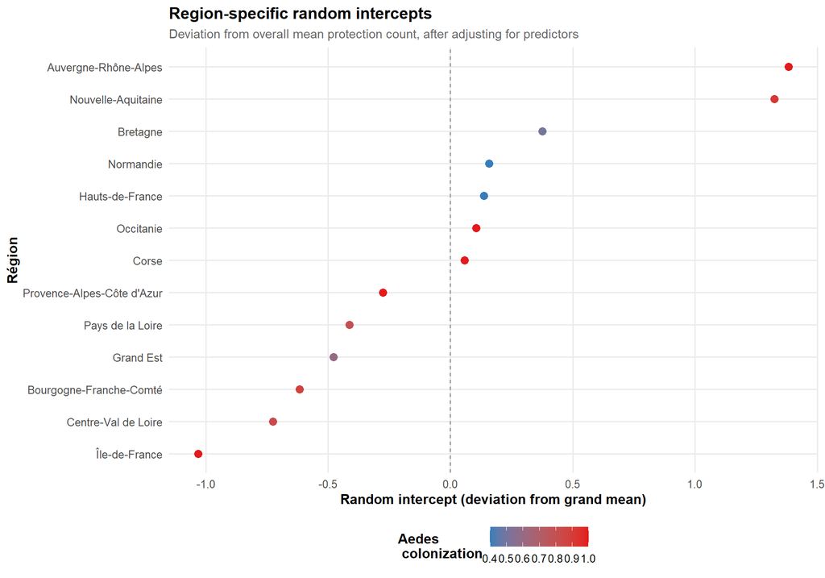

# 7 Effect visualization

## 7.1 Predictor effects plot

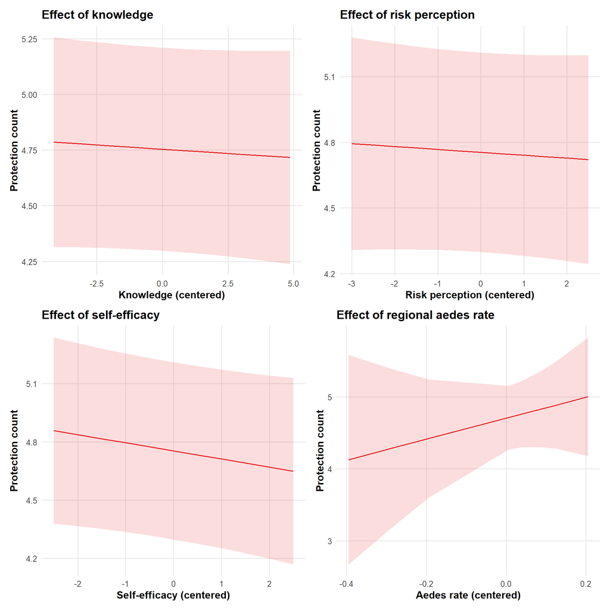

```r
# Create effect plots for key predictors
p_knowledge <- plot_model(final_model, type = "pred", terms = "knowledge_c") +
  labs(title = "Effect of knowledge", x = "Knowledge (centered)",
       y = "Protection count") +
  theme_mkp()

p_risk <- plot_model(final_model, type = "pred", terms = "risk_perception_c") +
  labs(title = "Effect of risk perception", x = "Risk perception (centered)",
       y = "Protection count") +
  theme_mkp()

p_efficacy <- plot_model(final_model, type = "pred", terms = "efficacy_c") +
  labs(title = "Effect of self-efficacy", x = "Self-efficacy (centered)",
       y = "Protection count") +
  theme_mkp()

p_aedes <- plot_model(final_model, type = "pred", terms = "aedes_rate_c") +
  labs(title = "Effect of regional aedes rate", x = "Aedes rate (centered)",
       y = "Protection count") +
  theme_mkp()

(p_knowledge | p_risk) / (p_efficacy | p_aedes)
```

## 7.2 Cross-Level interaction visualization (if significant)

```r
# Visualize cross-level interaction if Model 3 showed significance
interaction_coef <- tidy(model3, effects = "fixed") %>%
  filter(term == "knowledge_c:aedes_rate_c")

if (interaction_coef$p.value < 0.10) {
  plot_model(model3, type = "pred",
             terms = c("knowledge_c", "aedes_rate_c [-0.3, 0, 0.3]")) +
    labs(
      title = "Cross-Level interaction: Knowledge × Regional Aedes rate",
      subtitle = "Effect of knowledge on protection varies by regional colonization",
      x = "Knowledge (centered)",
      y = "Predicted protection count",
      color = "Aedes rate \n (centered)"
    ) +
    theme_mkp()
} else {
  cat("Cross-level interaction not significant at p < 0.10. \n ")
  cat("Knowledge effect is consistent across regions. \n ")
}
```

```
## Cross-level interaction not significant at p < 0.10.
##  Knowledge effect is consistent across regions.
##
```

# 8 Model diagnostics

## 8.1 Residual analysis

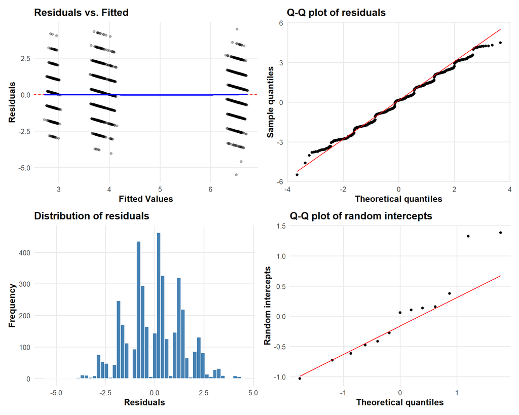

## 8.2 Influence diagnostics

```
## No regions identified as potentially influential.
##
```

# 9 Results summary

```
## MULTILEVEL ANALYSIS: KEY FINDINGS
##
```

```
## H1 (CLUSTERING):
##
```

```
##   ICC from null model: 0.556
##
```

```
##   Result:  SUPPORTED - Significant regional clustering
##
##
```

```
## H2 (COMPOSITIONAL EFFECTS):
##
```

```
##   Significant Level-1 predictors: 0 of 3 tested
##
```

[output not shown]

```
## H3 (CONTEXTUAL EFFECTS):
##
```

```
##   Aedes rate effect: B = 1.457 , p = 0.4279
##
```

```
##   Result: NOT SUPPORTED
##
##
```

```
## H4 (CROSS-LEVEL INTERACTION):
##
```

```
##   Knowledge × Aedes rate: p = 0.536
##
```

```
##   Result: NOT SUPPORTED
##
##
```

```
## H5 (VARIANCE REDUCTION):
##
```

```
##   Proportional reduction in Level-2 variance: 74.2 %
##
```

```
##   Result: SUPPORTED
##
##
```

```
## MODEL FIT:
##
```

```
##   Marginal R²: 0.3611
##
```

```
##   Conditional R²: 0.5173
##
```

# 10 Export results

```
## Results exported:
##
```

```
##   - multilevel_fixed_effects.csv
##
```

```
##   - multilevel_region_effects.csv
##
```

```
##   - multilevel_predictions.csv
##
```

# 11 Implications for MoustiKAP-P